# Hoja de Ejercicios 2

Como habíamos dicho anteriormente, cuantas más barras disponga el hsitograma se nos va a mostrar una informción más precisa y detallada, pero a su vez, como las barras van a ser más estrechas, nos van a dificultar su lectura.

6. **Continue exploring the data, and provide a brief summary of what you discover.**

```r
par(mfrow=c(1,3))
col=topo.colors(3,alpha =0.4)
hist( Apps, xlab="Number of applications received",ylim=c(0,700),breaks=10,col=col[1])
hist( Accept, xlab="Number of applicants accepted",ylim=c(0,700),breaks=10,col=col[2])
hist( Enroll, xlab="Number of new students enrolled",ylim=c(0,700),breaks=10,col=col[3])
```

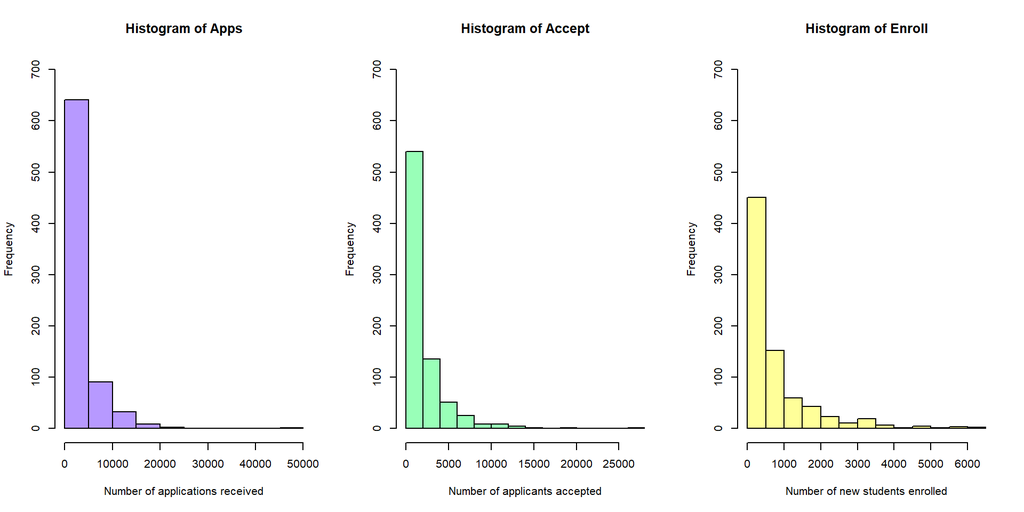

Como podemos observar, hay alrededor de unas 650 universidades que reciben un total de 5000 solucitudes y muy pocas que reciben unas 50000. La mayor parte de las universidades (un total de unos 550) aceptan unos 2500 estudiantes, pero al final solo se inscriben en mayor parte unos 500 estudiantes por universidad. Como podemos obervar en la gráfica en amarillo, en 450 universidades se aceptan a 500 estudiantes por curso.

En segundo lugar, vamos a estudiar un poco algunas variables del Data Frame y miraremos si podemos establecer alguna relación lineal entre ellas:

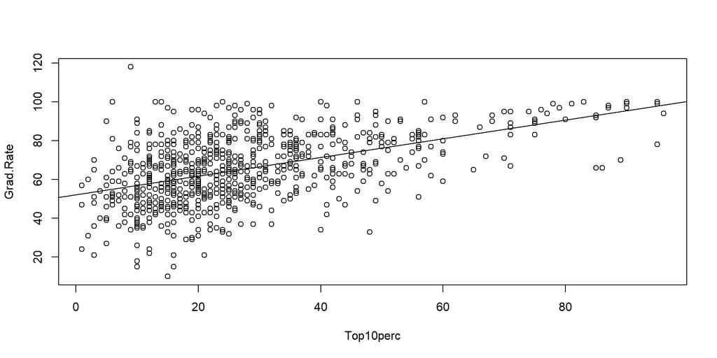

```r
plot(Grad.Rate~Top10perc, data = college)
abline(lm(Grad.Rate~Top10perc, data = college))
```

```r
summary(lm(Grad.Rate~Top10perc, data = college))$adj.r.squared
```

[output not shown]

[figure not shown]

Como podemos observar, hay alrededor de unas 650 universidades que reciben un total de 5000 solucitudes y muy pocas que reciben unas 50000. La mayor parte de las universidades (un total de unos 550) aceptan unos 2500 estudiantes, pero al final solo se inscriben en mayor parte unos 500 estudiantes por universidad. Como podemos obervar en la gráfica en amarillo, en 450 universidades se aceptan a 500 estudiantes por curso.

En segundo lugar, vamos a estudiar un poco algunas variables del Data Frame y miraremos si podemos establecer alguna relación lineal entre ellas:

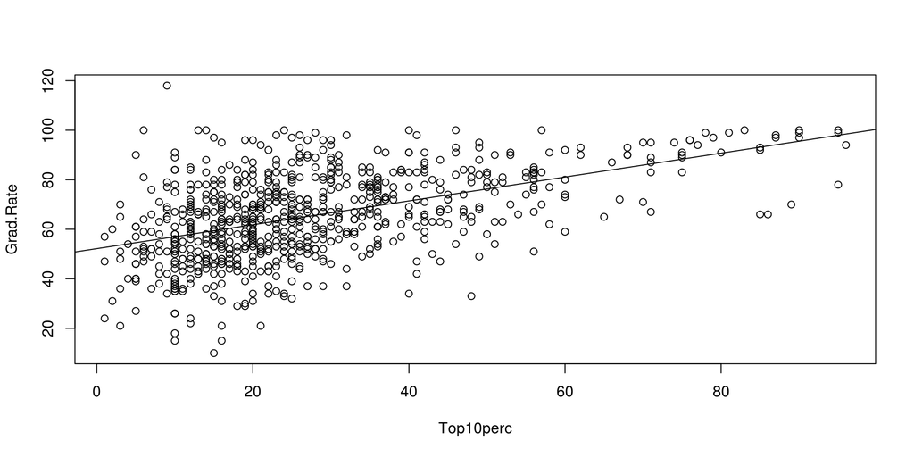

```r
plot(Grad.Rate~Top10perc, data = college)
abline(lm(Grad.Rate~Top10perc, data = college))
```

```r
summary(lm(Grad.Rate~Top10perc, data = college))$adj.r.squared
```

```
## [1] 0.2440402
```

```r
# summary(lm(Grad.Rate~Top10perc+, data = college))
```

Como podemos apreciar en la nube de puntos, a regresión lineal no explica demasiado bien la relación entre las variables *Grad.Rate* y *Top10perc*. El coeficiente de ajuste nos confirma nuestra sopecha, que obtenemos un valor muy bajo. En definitiva la variable que indica el nombre de alumnos matriculados que pertenecian al Top10 en High school no explica demasiado bien linealmente el comportamiendo del número de graduados.

Probemos con otra regresión:

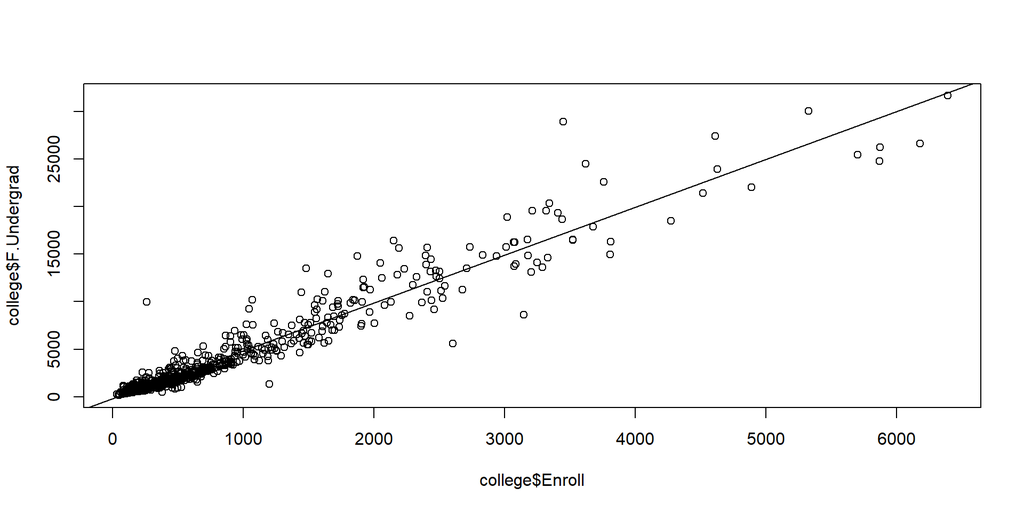

```r
plot(college$Enroll, college$F.Undergrad)
abline(lm(college$F.Undergrad~ college$Enroll))
```

```r
summary(lm(college$F.Undergrad~ college$Enroll))$adj.r.squared
```

```
## [1] 0.93044
```

Como podemos observar, con el coefiente de correlación es muy cercano a uno, lo que significa que la recta ajusta bastante bien los datos. Este hecho ya se podría apreciar en la nube de puntos.

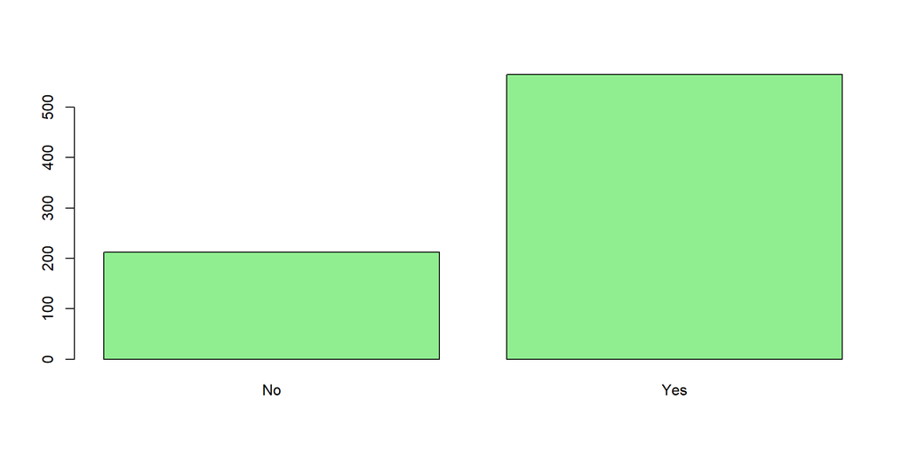

```r
plot(college$Private, col='lightgreen')
```

[figure not shown]

```r
plot(college$Enroll, college$F.Undergrad)
abline(lm(college$F.Undergrad~ college$Enroll))
```

```r
summary(lm(college$F.Undergrad~ college$Enroll))$adj.r.squared
```

```
## [1] 0.93044
```

Como podemos observar, con el coefiente de correlación es muy cercano a uno, lo que significa que la recta ajusta bastante bien los datos. Este hecho ya se podría apreciar en la nube de puntos.